# Demo

Shuyu Li

2025-05-24

# Load Bio3d

```r
library(bio3d)
```

# Working with Individual PDB Files

```r
# get structure from PDB server
RFP <- read.pdb("1ZGO") # 1ZGO.pdb is the PDB file of a red fluorescent protein (dsRed)
```

```
##   Note: Accessing on-line PDB file
##    PDB has ALT records, taking A only, rm.alt=TRUE
```

```r
RFP
```

```
##
##  Call:  read.pdb(file = "1ZGO")
##
##    Total Models#: 1
##      Total Atoms#: 7699,  XYZs#: 23097  Chains#: 4  (values: A B C D)
##
##      Protein Atoms#: 7068  (residues/Calpha atoms#: 868)
##      Nucleic acid Atoms#: 0  (residues/phosphate atoms#: 0)
##
##      Non-protein/nucleic Atoms#: 631  (residues: 539)
##      Non-protein/nucleic resid values: [ CRQ (4), HOH (535) ]
##
##    Protein sequence:
##       NVIKEFMRFKVRMEGTVNGHEFEIEGEGEGRPYEGHNTVKLKVTKGGPLPFAWDILSPQF
##       SKVYVKHPADIPDYKKLSFPEGFKWERVMNFEDGGVVTVTQDSSLQDGCFIYKVKFIGVN
##       FPSDGPVMQKKTMGWEASTERLYPRDGVLKGEIHKALKLKDGGHYLVEFKSIYMAKKPVQ
##       LPGYYYVDSKLDITSHNEDYTIVEQYERTEGRHHLFLNVIKEFMR...<cut>...HLFL
##
## + attr: atom, xyz, seqres, helix, sheet,
##         calpha, remark, call
```

use `attributes(pdb)` to list components that comprise the pdb object. Each individual component can be accessed by using the $.

```r
# can find out the attributes of an object by:
attributes(RFP)
```

```
## $names
## [1] "atom"   "xyz"    "seqres" "helix"  "sheet"  "calpha" "remark" "call"
##
## $class
## [1] "pdb" "sse"
```

```r
# can access individual attributes by object_name$attribute_name
print(RFP$atom) # show each atom's information
```

```
##        type eleno elety  alt resid chain resno insert       x       y      z
## 1      ATOM     1     N <NA>   ASN     A     6   <NA>  11.586 -26.305 61.258
## 2      ATOM     2    CA <NA>   ASN     A     6   <NA>  12.992 -25.901 61.111
## 3      ATOM     3     C <NA>   ASN     A     6   <NA>  13.718 -26.795 60.105
## 4      ATOM     4     O <NA>   ASN     A     6   <NA>  14.760 -27.386 60.396
## 5      ATOM     5    CB <NA>   ASN     A     6   <NA>  13.700 -25.896 62.458
## 6      ATOM     6    CG <NA>   ASN     A     6   <NA>  15.127 -26.398 62.459
## 7      ATOM     7   OD1 <NA>   ASN     A     6   <NA>  15.755 -26.626 61.423
## 8      ATOM     8   ND2 <NA>   ASN     A     6   <NA>  15.666 -26.584 63.668
## 9      ATOM     9     N <NA>   VAL     A     7   <NA>  13.143 -26.869 58.910
## 10     ATOM    10    CA <NA>   VAL     A     7   <NA>  13.605 -27.720 57.828
## 11     ATOM    11     C <NA>   VAL     A     7   <NA>  14.734 -27.103 57.026
## 12     ATOM    12     O <NA>   VAL     A     7   <NA>  15.328 -27.763 56.157
## 13     ATOM    13    CB <NA>   VAL     A     7   <NA>  12.428 -28.018 56.873
## 14     ATOM    14   CG1 <NA>   VAL     A     7   <NA>  11.392 -28.934 57.504
```

[output cut: 12486 more lines]

```r
print(RFP$helix)
```

```
## $start
##
## 57 69 81 57 69 81 57 69 81 57 69 81
##
## $end
##
## 65 73 86 65 73 86 65 73 86 65 73 86
##
## $chain
##  [1] "A" "A" "A" "B" "B" "B" "C" "C" "C" "D" "D" "D"
##
## $type
##  [1] "5" "5" "1" "5" "5" "1" "5" "5" "1" "5" "5" "1"
```

```r
print(RFP$sheet)
```

```
## $start
##
## 140 156 172  91 104 117  12  25  41 210 193 146 140 156 172  91 104 117  12  25
##
##  41 210 193 146 140 156 172  91 104 117  12  25  41 210 193 146 140 156 172  91
##
## 104 117  12  25  41 210 193 146
##
## $end
##
## 143 167 183  99 114 127  22  36  50 220 204 153 143 167 183  99 114 127  22  35
##
##  50 220 204 153 143 167 183  99 114 127  22  36  50 220 204 153 143 167 183  99
##
## 114 127  22  36  50 220 204 153
##
## $chain
##  [1] "A" "A" "A" "A" "A" "A" "A" "A" "A" "A" "A" "A" "B" "B" "B" "B" "B" "B" "B"
## [20] "B" "B" "B" "B" "B" "C" "C" "C" "C" "C" "C" "C" "C" "C" "C" "C" "C" "D" "D"
## [39] "D" "D" "D" "D" "D" "D" "D" "D" "D" "D"
##
## $sense
##  [1] "0"  "-1" "-1" "-1" "-1" "-1" "1"  "-1" "-1" "-1" "-1" "-1" "0"  "-1" "-1"
## [16] "-1" "-1" "-1" "1"  "-1" "-1" "-1" "-1" "-1" "0"  "-1" "-1" "-1" "-1" "-1"
## [31] "1"  "-1" "-1" "-1" "-1" "-1" "0"  "-1" "-1" "-1" "-1" "-1" "1"  "-1" "-1"
## [46] "-1" "-1" "-1"
```

```r
print(RFP$calpha) # the bool values show whether an atom is C alpha atom
```

```
##    [1] FALSE  TRUE FALSE FALSE FALSE FALSE FALSE FALSE FALSE  TRUE FALSE FALSE
##   [13] FALSE FALSE FALSE FALSE  TRUE FALSE FALSE FALSE FALSE FALSE FALSE FALSE
##   [25]  TRUE FALSE FALSE FALSE FALSE FALSE FALSE FALSE FALSE  TRUE FALSE FALSE
##   [37] FALSE FALSE FALSE FALSE FALSE FALSE  TRUE FALSE FALSE FALSE FALSE FALSE
##   [49] FALSE FALSE FALSE FALSE FALSE  TRUE FALSE FALSE FALSE FALSE FALSE FALSE
##   [61] FALSE  TRUE FALSE FALSE FALSE FALSE FALSE FALSE FALSE FALSE FALSE FALSE
##   [73]  TRUE FALSE FALSE FALSE FALSE FALSE FALSE FALSE FALSE FALSE FALSE  TRUE
##   [85] FALSE FALSE FALSE FALSE FALSE FALSE FALSE FALSE  TRUE FALSE FALSE FALSE
##   [97] FALSE FALSE FALSE  TRUE FALSE FALSE FALSE FALSE FALSE FALSE FALSE FALSE
##  [109] FALSE FALSE  TRUE FALSE FALSE FALSE FALSE FALSE FALSE FALSE  TRUE FALSE
##  [121] FALSE FALSE FALSE FALSE FALSE FALSE FALSE  TRUE FALSE FALSE FALSE  TRUE
##  [133] FALSE FALSE FALSE FALSE FALSE FALSE  TRUE FALSE FALSE FALSE FALSE FALSE
##  [145] FALSE  TRUE FALSE FALSE FALSE FALSE FALSE FALSE FALSE  TRUE FALSE FALSE
##  [157] FALSE  TRUE FALSE FALSE FALSE FALSE FALSE FALSE FALSE FALSE FALSE  TRUE
##  [169] FALSE FALSE FALSE FALSE FALSE FALSE FALSE FALSE  TRUE FALSE FALSE FALSE
```

[output cut: 627 more lines]

```r
# Print $atom data for the first two atoms
RFP$atom[1:2, ]
```

```
##   type eleno elety  alt resid chain resno insert      x       y      z o     b
## 1 ATOM     1     N <NA>   ASN     A     6   <NA> 11.586 -26.305 61.258 1 55.00
## 2 ATOM     2    CA <NA>   ASN     A     6   <NA> 12.992 -25.901 61.111 1 52.49
##   segid elesy charge
## 1  <NA>     N   <NA>
## 2  <NA>     C   <NA>
```

```r
# Print a subset of $atom data for the first two atoms
RFP$atom[1:2, c("eleno", "elety", "resid", "x", "y", "z")]
```

```
##   eleno elety resid      x       y      z
## 1     1     N   ASN 11.586 -26.305 61.258
## 2     2    CA   ASN 12.992 -25.901 61.111
```

## Plot the Ca’s B-factor

The **B-factor** (also known as the temperature factor) in a PDB file represents the atomic displacement or flexibility of atoms in a protein structure. It provides insight into how much an atom moves within the crystal structure due to thermal vibrations or disorder.

- Higher B-factor → Indicates greater movement or flexibility.
- Lower B-factor → Suggests a more stable and rigid atomic position.

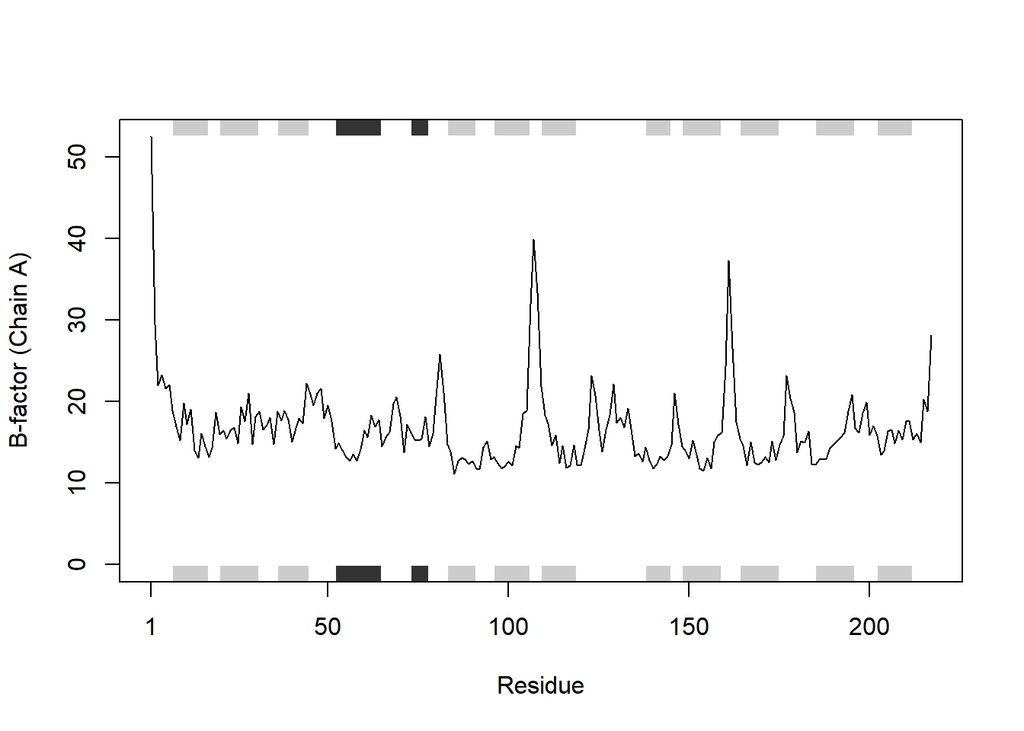

```r
# extract all information about chain A
RFP_A <- trim(RFP, chain = "A", elety = "CA")
# extract B-factors of atoms on chain A
b_chain_A <- RFP_A$atom$b
# plot
plot.bio3d(b_chain_A, sse = RFP_A, typ = "l", ylab = "B-factor (Chain A)")
```

**Side-note:** The “RFP” object created above also has a second class, namely “sse” (see the output of `attributes(RFP)` or `class(RFP)`). This stands for *secondary structure elements* and is recognized by the `plot.bio3d()` function to annotate the positions of major secondary structure elements in the marginal regions of these plots.

## Plot the Torsion/Dihedral Analysis

The conformation of a polypeptide or nucleotide chain can be usefully described in terms of angles of internal rotation around its constituent bonds.

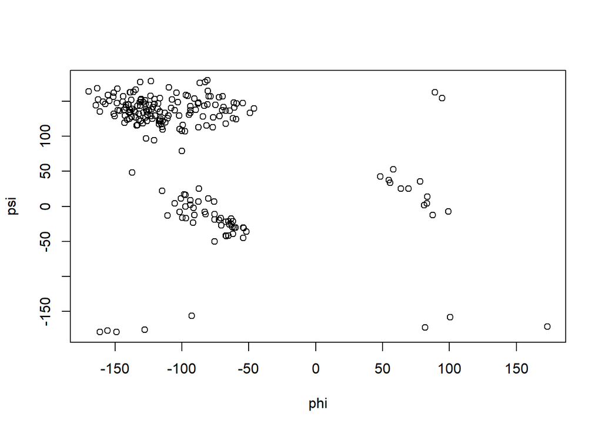

```r
tor <- torsion.pdb(trim(RFP, chain = "A"))
# Basic Ramachandran plot
plot(tor$phi, tor$psi, xlab="phi", ylab="psi")
```

## Atom Selection

### Normal Selection

`atom.select()` operates on PDB structure objects (as created by `read.pdb()`) and returns the numeric indices of a selected atom subset. These indices can then be used to access the `$atom` and `$xyz` attributes of PDB structure related objects.

```r
# select indices for all Ca atoms
ca.inds <- atom.select(RFP, "calpha")
print(ca.inds)
```

```
##
##  Call:  atom.select.pdb(pdb = RFP, string = "calpha")
##
##    Atom Indices#: 868  ($atom)
##    XYZ  Indices#: 2604  ($xyz)
##
## + attr: atom, xyz, call
```

Note that the attributes of the returned `ca.inds` from `atom.select()` include both `atom` and `xyz` components. These are numeric vectors that can be used as indices to access the corresponding atom and xyz components of the input PDB structure object.

`ca.inds` is a list with the following components:

- `atom` → A numeric vector of atomic indices (which atoms are selected).
- `xyz` → A numeric vector of XYZ coordinate indices (which coordinates correspond to the selected atoms).
- `call` → The matched function call (for reference).

```r
# print details of all Ca atoms
print(RFP$atom[ca.inds$atom, ])
```

```
##      type eleno elety  alt resid chain resno insert       x       y      z    o
## 2    ATOM     2    CA <NA>   ASN     A     6   <NA>  12.992 -25.901 61.111 1.00
## 10   ATOM    10    CA <NA>   VAL     A     7   <NA>  13.605 -27.720 57.828 1.00
## 17   ATOM    17    CA <NA>   ILE     A     8   <NA>  16.211 -25.318 56.484 1.00
## 25   ATOM    25    CA <NA>   LYS     A     9   <NA>  19.561 -26.588 57.742 1.00
## 34   ATOM    34    CA <NA>   GLU     A    10   <NA>  22.827 -24.683 57.755 1.00
## 43   ATOM    43    CA <NA>   PHE     A    11   <NA>  23.875 -26.755 54.698 1.00
## 54   ATOM    54    CA <NA>   MET     A    12   <NA>  21.379 -27.608 51.949 1.00
## 62   ATOM    62    CA <NA>   ARG     A    13   <NA>  21.617 -29.192 48.538 1.00
## 73   ATOM    73    CA <NA>   PHE     A    14   <NA>  19.434 -28.726 45.485 1.00
## 84   ATOM    84    CA <NA>   LYS     A    15   <NA>  18.626 -30.243 42.111 1.00
## 93   ATOM    93    CA <NA>   VAL     A    16   <NA>  17.456 -28.175 39.138 1.00
## 100  ATOM   100    CA <NA>   ARG     A    17   <NA>  16.011 -28.707 35.663 1.00
## 111  ATOM   111    CA <NA>   MET     A    18   <NA>  15.353 -26.043 33.015 1.00
## 119  ATOM   119    CA <NA>   GLU     A    19   <NA>  13.411 -26.303 29.731 1.00
```

[output cut: 1723 more lines]

```r
# print xyz coordinates of first few Ca
head(RFP$xyz[ ,ca.inds$xyz])
```

```
## [1]  12.992 -25.901  61.111  13.605 -27.720  57.828
```

In Bio3D, besides using common selection strings like `"calpha"`, `"cbeta"`, `"backbone"`, `"protein"`, `"ligand"`, `"water"`, etc., you can also select atoms based on specific properties such as:

- Atom Name (`elety`) → Select atoms by their element type (e.g., `"CA"` for C-alpha, `"O"` for oxygen).
- Residue Name (`resid`) → Select atoms belonging to specific residues (e.g., `"ALA"` for alanine).
- Residue Number (`resno`) → Select atoms by residue index.
- Chain ID (`chain`) → Select atoms from a specific chain (e.g., `"A"` for chain A).
- Segment ID (`segid`) → Select atoms based on segment identifiers.
- Insertion Code (`insert`) → Select atoms with specific insertion codes.
- Element Number (`eleno`) → Select atoms by their unique element number.

```r
# select chain A
a.inds <- atom.select(RFP, chain = "A")

# select Ca atoms on Chain A
aca.inds <- atom.select(RFP, "calpha", chain = "A")

# Combine multiple selection criteria
cab.inds <- atom.select(RFP, chain = "A", elety = c("CA", "CB"), resno = 10:20)
cb30.inds <- atom.select(RFP, chain = "A", elety = "CB", resno = 30 )
```

### Inverse Selection

Inverse selection is select all atoms except the atoms passed to the function.

```r
nowater.inds <- atom.select(RFP, "water", inverse = TRUE)
```

### Combing Selections

in `atom.select()`, the default parameter of operator is operator = “AND”. When multiple selection criteria are used, only atoms that satisfy ALL conditions are selected. If change operator = “OR”, it will broaden the selection by including atoms that satisfy at least one of the conditions.

```r
# select protein and GDP
sele <- atom.select(RFP, "protein", resid = "GDP", operator = "OR")
```

Function `combine.select()` provides further functionality to combine selections. For example the above selection of protein and GDP can be completed with:

```r
protein.inds <- atom.select(RFP, "protein")
gdp.inds <- atom.select(RFP, resid = "GDP")
sele <- combine.select(protein.inds, gdp.inds, operator = "OR")
```

```
##  Union of selects
##  *  Selected a total of: 7068 atoms  *
```

# Write a PDB Object

Use the command `write.pdb()` to output a structure object to a PDB formatted file on your local hard drive. Below we use function `atom.select()` to select only the backbone atoms, and `trim.pdb()` to create a new PDB object based on our selection of backbone atoms. Finally we use the function `write.pdb()` to write the newly generated PDB file containing only the backbone atoms:

```r
backbone.inds <- atom.select(RFP_A, "back")
help("trim.pdb")
```

```
## starting httpd help server ... done
```

```r
backbone_pdb <- trim.pdb(RFP_A, backbone.inds, sse = "TRUE")
write.pdb(backbone_pdb, file = "1ZGO_BB.pdb")
```

**Side-note:** function `atom.select()` can also return the resulting trimmed `pdb` object using the optional argument `value=TRUE`.

# Working With Multiple PDB Files

Use `get.pdb()` to download multiple PDB files from PDB database.

```r
# these are some normal green fluorescent proteins
ids <- c("1GFL_A","2B3P_A","2Y0G_A","1QYO_A")
raw.files <- get.pdb(ids)
```

Use `pdbsplit()` to extract the particular chains from pdb files. Then use `pdbaln()` to align requested chains structural data.

```r
files <- pdbsplit(raw.files, ids)
```

[output not shown]

```r
GFPs <- pdbaln(files)
```

```
## Reading PDB files:
## split_chain/1GFL_A.pdb
## split_chain/2B3P_A.pdb
## split_chain/2Y0G_A.pdb
## split_chain/1QYO_A.pdb
## ..   PDB has ALT records, taking A only, rm.alt=TRUE
## ..
##
## Extracting sequences
##
## pdb/seq: 1   name: split_chain/1GFL_A.pdb
## pdb/seq: 2   name: split_chain/2B3P_A.pdb
## pdb/seq: 3   name: split_chain/2Y0G_A.pdb
##    PDB has ALT records, taking A only, rm.alt=TRUE
## pdb/seq: 4   name: split_chain/1QYO_A.pdb
```

## Calculate Sequence Identity

```r
GFPs$id <- substr(basename(GFPs$id), 1, 4)
seqidentity(GFPs)
```

```
##       1GFL  2B3P  2Y0G  1QYO
## 1GFL 1.000 0.956 0.991 0.969
## 2B3P 0.956 1.000 0.956 0.969
## 2Y0G 0.991 0.956 1.000 0.987
## 1QYO 0.969 0.969 0.987 1.000
```

## Calculate RMSD

```r
rmsd(GFPs, fit=TRUE) # fit=TRUE: superimpose all structures to a reference before computing RMSD
```

```
##       1GFL  2B3P  2Y0G  1QYO
## 1GFL 0.000 0.800 0.364 0.360
## 2B3P 0.800 0.000 0.799 0.813
## 2Y0G 0.364 0.799 0.000 0.321
## 1QYO 0.360 0.813 0.321 0.000
```

# Constructing experimental structure ensembles for a protein family

Comparing multiple structures of homologous proteins and carefully analyzing large multiple sequence alignments can help identify patterns of sequence and structural conservation and highlight conserved interactions that are crucial for protein stability and function (Grant et al. 2007).

In here, I didn’t use `blast()` function in Bio3D to search possible homologous sequences. I blast on NCBI database and download the structures from PDB database directly.

```r
pdb_dir <- "./FPs"
pdb_files <- list.files(pdb_dir, pattern="\\.pdb$", full.names=TRUE)

# extract PDB ID from file names
pdb_ids <- toupper(tools::file_path_sans_ext(basename(pdb_files)))
print(pdb_ids)
```

```
##  [1] "1EMA" "1GFL" "1MYW" "1QYO" "1ZGO" "2B3P" "2B3Q" "2H5O" "2H5Q" "2H5R"
## [11] "2QLG" "2V4E" "2VAD" "2VAE" "2WSO" "2Y0G" "2YDZ" "3NED" "3NEZ" "3ZTF"
## [21] "4AR7" "4EUL" "4H3L" "4KF4" "4OQW" "4Q7R" "4Q7T" "4Q7U" "5DRG" "5DTZ"
## [31] "5JZK" "5JZL" "5LK4" "5LTP" "5OX8" "5WJ2" "7OIN" "7UGR" "7UGS" "7ZCT"
```

```r
# annotate each structure
anno <- pdb.annotate(pdb_ids)
anno[, c("resolution", "source", "structureTitle", "citation")]
```

```
##        resolution                    source
## 1EMA_A      1.900         Aequorea victoria
## 1GFL_B      1.900         Aequorea victoria
## 1GFL_A      1.900         Aequorea victoria
## 1MYW_A      2.200         Aequorea victoria
## 1QYO_A      1.800         Aequorea victoria
## 1ZGO_A      1.400             Discosoma sp.
## 1ZGO_C      1.400             Discosoma sp.
## 1ZGO_D      1.400             Discosoma sp.
## 1ZGO_B      1.400             Discosoma sp.
## 2B3P_A      1.400         Aequorea victoria
## 2B3Q_B      2.300         Aequorea victoria
## 2B3Q_C      2.300         Aequorea victoria
## 2B3Q_D      2.300         Aequorea victoria
## 2B3Q_A      2.300         Aequorea victoria
## 2H5O_A      1.080             Discosoma sp.
## 2H5O_B      1.080             Discosoma sp.
## 2H5Q_A      1.360             Discosoma sp.
## 2H5R_A      1.600             Discosoma sp.
## 2QLG_A      1.800     Discosoma sp. LW-2004
## 2QLG_B      1.800     Discosoma sp. LW-2004
## 2V4E_A      2.400             Discosoma sp.
## 2V4E_C      2.400             Discosoma sp.
## 2V4E_D      2.400             Discosoma sp.
## 2V4E_E      2.400             Discosoma sp.
## 2V4E_F      2.400             Discosoma sp.
## 2V4E_H      2.400             Discosoma sp.
## 2V4E_G      2.400             Discosoma sp.
## 2V4E_B      2.400             Discosoma sp.
## 2VAD_A      1.590             Discosoma sp.
## 2VAE_A      1.640             Discosoma sp.
## 2VAE_B      1.640             Discosoma sp.
## 2VAE_C      1.640             Discosoma sp.
## 2VAE_D      1.640             Discosoma sp.
## 2VAE_E      1.640             Discosoma sp.
## 2VAE_F      1.640             Discosoma sp.
## 2VAE_G      1.640             Discosoma sp.
## 2VAE_H      1.640             Discosoma sp.
## 2WSO_A      1.150         Aequorea victoria
## 2Y0G_A      1.500         Aequorea victoria
```

[output cut: 233 more lines]

```
## 5LK4_A                                        Bindels, D.S., et al. Nat Methods (2017)
## 5LTP_A                        Clavel, D., et al. Acta Crystallogr D Struct Biol (2016)
## 5LTP_B                        Clavel, D., et al. Acta Crystallogr D Struct Biol (2016)
## 5LTP_C                        Clavel, D., et al. Acta Crystallogr D Struct Biol (2016)
## 5LTP_F                        Clavel, D., et al. Acta Crystallogr D Struct Biol (2016)
## 5LTP_D                        Clavel, D., et al. Acta Crystallogr D Struct Biol (2016)
## 5LTP_E                        Clavel, D., et al. Acta Crystallogr D Struct Biol (2016)
## 5OX8_A                                        Gotthard, G., et al. Biochemistry (2017)
## 5WJ2_A                                         Campbell, B.C., et al. Structure (2018)
## 5WJ2_B                                         Campbell, B.C., et al. Structure (2018)
## 7OIN_B                                       Subach, O.M., et al. Int J Mol Sci (2021)
## 7UGR_A                                       Campbell, B.C., et al. Nat Methods (2022)
## 7UGS_A                                       Campbell, B.C., et al. Nat Methods (2022)
## 7ZCT_A                                  Gadella Jr., T.W.J., et al. Nat Methods (2023)
## 7ZCT_B                                  Gadella Jr., T.W.J., et al. Nat Methods (2023)
```

## Multiple Sequences Alignment

```r
# extract chian A from each raw PDB files
output_dir <- "FPs_chain_A"
dir.create(output_dir, showWarnings = FALSE)

files <- list.files(pdb_dir, pattern = "\\.pdb$", full.names = TRUE)

for (f in files) {
  cat("Processing:", basename(f), "\n")
  pdb <- tryCatch(read.pdb(f), error = function(e) NULL)
  if (is.null(pdb)) {
    cat(" - Skipping: read.pdb failed\n")
    next
  }

  pdb_A <- tryCatch(trim(pdb, chain = "A", elety = "CA"), error = function(e) NULL)
  if (is.null(pdb_A) || is.null(pdb_A$atom) || nrow(pdb_A$atom) == 0) {
    cat(" - Skipping: no A chain or no CA atoms\n")
    next
  }

  out_path <- file.path(output_dir, basename(f))
  tryCatch({
    write.pdb(pdb_A, file = out_path)
  }, error = function(e) {
    cat(" - Failed to write:", basename(f), "\n")
  })
}
```

```
## Processing: 1ema.pdb
## Processing: 1gfl.pdb
## Processing: 1myw.pdb
## Processing: 1qyo.pdb
## Processing: 1zgo.pdb
##    PDB has ALT records, taking A only, rm.alt=TRUE
## Processing: 2b3p.pdb
## Processing: 2b3q.pdb
## Processing: 2h5o.pdb
##    PDB has ALT records, taking A only, rm.alt=TRUE
## Processing: 2h5q.pdb
##    PDB has ALT records, taking A only, rm.alt=TRUE
## Processing: 2h5r.pdb
##    PDB has ALT records, taking A only, rm.alt=TRUE
## Processing: 2qlg.pdb
## Processing: 2v4e.pdb
## Processing: 2vad.pdb
##    PDB has ALT records, taking A only, rm.alt=TRUE
## Processing: 2vae.pdb
##    PDB has ALT records, taking A only, rm.alt=TRUE
## Processing: 2wso.pdb
##    PDB has ALT records, taking A only, rm.alt=TRUE
## Processing: 2y0g.pdb
##    PDB has ALT records, taking A only, rm.alt=TRUE
## Processing: 2ydz.pdb
##    PDB has ALT records, taking A only, rm.alt=TRUE
## Processing: 3ned.pdb
##    PDB has ALT records, taking A only, rm.alt=TRUE
## Processing: 3nez.pdb
##    PDB has ALT records, taking A only, rm.alt=TRUE
## Processing: 3ztf.pdb
##    PDB has ALT records, taking A only, rm.alt=TRUE
## Processing: 4ar7.pdb
##    PDB has ALT records, taking A only, rm.alt=TRUE
## Processing: 4eul.pdb
##    PDB has ALT records, taking A only, rm.alt=TRUE
## Processing: 4h3l.pdb
##    PDB has ALT records, taking A only, rm.alt=TRUE
## Processing: 4kf4.pdb
##    PDB has ALT records, taking A only, rm.alt=TRUE
```

[output cut: 15 more lines]

```
## Processing: 5lk4.pdb
##    PDB has ALT records, taking A only, rm.alt=TRUE
## Processing: 5ltp.pdb
##    PDB has ALT records, taking A only, rm.alt=TRUE
## Processing: 5ox8.pdb
##    PDB has ALT records, taking A only, rm.alt=TRUE
## Processing: 5wj2.pdb
## Processing: 7oin.pdb
##    PDB has ALT records, taking A only, rm.alt=TRUE
##  - Skipping: no A chain or no CA atoms
## Processing: 7ugr.pdb
## Processing: 7ugs.pdb
##    PDB has ALT records, taking A only, rm.alt=TRUE
## Processing: 7zct.pdb
##    PDB has ALT records, taking A only, rm.alt=TRUE
```

```r
files <- list.files("FPs_chain_A", pattern = "\\.pdb$", full.names = TRUE)
files <- files[file.exists(files) & !is.na(files)]
# alignment
pdbs <- pdbaln(files, exepath = muscle.path)
```

```
## Reading PDB files:
## FPs_chain_A/1ema.pdb
## FPs_chain_A/1gfl.pdb
## FPs_chain_A/1myw.pdb
## FPs_chain_A/1qyo.pdb
## FPs_chain_A/1zgo.pdb
## FPs_chain_A/2b3p.pdb
## FPs_chain_A/2b3q.pdb
## FPs_chain_A/2h5o.pdb
## FPs_chain_A/2h5q.pdb
## FPs_chain_A/2h5r.pdb
## FPs_chain_A/2qlg.pdb
## FPs_chain_A/2v4e.pdb
## FPs_chain_A/2vad.pdb
## FPs_chain_A/2vae.pdb
## FPs_chain_A/2wso.pdb
## FPs_chain_A/2y0g.pdb
## FPs_chain_A/2ydz.pdb
## FPs_chain_A/3ned.pdb
## FPs_chain_A/3nez.pdb
## FPs_chain_A/3ztf.pdb
## FPs_chain_A/4ar7.pdb
## FPs_chain_A/4eul.pdb
## FPs_chain_A/4h3l.pdb
## FPs_chain_A/4kf4.pdb
## FPs_chain_A/4oqw.pdb
## FPs_chain_A/4q7r.pdb
## FPs_chain_A/4q7t.pdb
## FPs_chain_A/4q7u.pdb
## FPs_chain_A/5drg.pdb
## FPs_chain_A/5dtz.pdb
## FPs_chain_A/5jzk.pdb
## FPs_chain_A/5jzl.pdb
## FPs_chain_A/5lk4.pdb
## FPs_chain_A/5ltp.pdb
## FPs_chain_A/5ox8.pdb
## FPs_chain_A/5wj2.pdb
## FPs_chain_A/7ugr.pdb
## FPs_chain_A/7ugs.pdb
## FPs_chain_A/7zct.pdb
```

[output cut: 74 more lines]

```
##    PDB has ALT records, taking A only, rm.alt=TRUE
## pdb/seq: 32   name: FPs_chain_A/5jzl.pdb
##    PDB has ALT records, taking A only, rm.alt=TRUE
## pdb/seq: 33   name: FPs_chain_A/5lk4.pdb
##    PDB has ALT records, taking A only, rm.alt=TRUE
## pdb/seq: 34   name: FPs_chain_A/5ltp.pdb
##    PDB has ALT records, taking A only, rm.alt=TRUE
## pdb/seq: 35   name: FPs_chain_A/5ox8.pdb
##    PDB has ALT records, taking A only, rm.alt=TRUE
## pdb/seq: 36   name: FPs_chain_A/5wj2.pdb
## pdb/seq: 37   name: FPs_chain_A/7ugr.pdb
## pdb/seq: 38   name: FPs_chain_A/7ugs.pdb
##    PDB has ALT records, taking A only, rm.alt=TRUE
## pdb/seq: 39   name: FPs_chain_A/7zct.pdb
##    PDB has ALT records, taking A only, rm.alt=TRUE
```

## Comparative structure analysis

The detailed comparison of homologous protein structures can be used to infer pathways for evolutionary adaptation and, at closer evolutionary distances, mechanisms for conformational change.

### Structure superposition

The Bio3D `core.find()` function implements an iterated superposition procedure, where residues displaying the largest positional differences are identified and excluded at each round. The function returns an ordered list of excluded residues, from which the user can select a subset of ’core’ residues upon which superposition can be based.

```r
# Identify the conserved core regions from the aligned structures
core <- core.find(pdbs)
```

```
##  core size 200 of 201  vol = 75.217
##  core size 199 of 201  vol = 71.337
##  core size 198 of 201  vol = 68.411
##  core size 197 of 201  vol = 65.401
##  core size 196 of 201  vol = 61.973
##  core size 195 of 201  vol = 59.297
##  core size 194 of 201  vol = 57.389
##  core size 193 of 201  vol = 55.49
##  core size 192 of 201  vol = 53.404
##  core size 191 of 201  vol = 51.622
##  core size 190 of 201  vol = 49.34
##  core size 189 of 201  vol = 47.969
##  core size 188 of 201  vol = 46.662
##  core size 187 of 201  vol = 45.546
##  core size 186 of 201  vol = 44.494
##  core size 185 of 201  vol = 42.857
##  core size 184 of 201  vol = 42.05
##  core size 183 of 201  vol = 40.8
##  core size 182 of 201  vol = 39.432
##  core size 181 of 201  vol = 37.984
##  core size 180 of 201  vol = 37.079
##  core size 179 of 201  vol = 36.241
##  core size 178 of 201  vol = 35.509
##  core size 177 of 201  vol = 34.27
##  core size 176 of 201  vol = 33.149
##  core size 175 of 201  vol = 32.03
##  core size 174 of 201  vol = 30.746
##  core size 173 of 201  vol = 29.452
##  core size 172 of 201  vol = 28.274
##  core size 171 of 201  vol = 27.256
##  core size 170 of 201  vol = 26.017
##  core size 169 of 201  vol = 25.011
##  core size 168 of 201  vol = 24.123
##  core size 167 of 201  vol = 22.953
##  core size 166 of 201  vol = 21.979
##  core size 165 of 201  vol = 20.759
##  core size 164 of 201  vol = 20.184
##  core size 163 of 201  vol = 19.504
##  core size 162 of 201  vol = 18.987
##  core size 161 of 201  vol = 18.063
```

[output cut: 90 more lines]

```
##  core size 70 of 201  vol = 0.806
##  core size 69 of 201  vol = 0.773
##  core size 68 of 201  vol = 0.742
##  core size 67 of 201  vol = 0.711
##  core size 66 of 201  vol = 0.684
##  core size 65 of 201  vol = 0.662
##  core size 64 of 201  vol = 0.639
##  core size 63 of 201  vol = 0.616
##  core size 62 of 201  vol = 0.592
##  core size 61 of 201  vol = 0.574
##  core size 60 of 201  vol = 0.553
##  core size 59 of 201  vol = 0.531
##  core size 58 of 201  vol = 0.508
##  core size 57 of 201  vol = 0.493
##  FINISHED: Min vol ( 0.5 ) reached
```

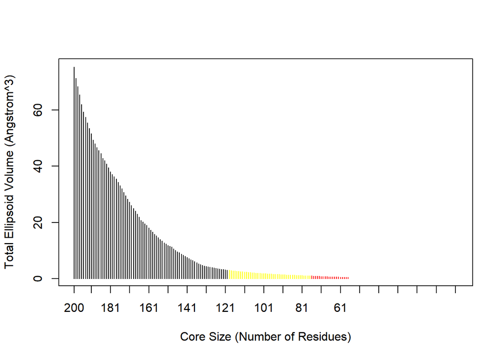

```r
# Color coding the core residues based on their positional variance (volume)
# Positions with variance < 3 are colored yellow (moderately conserved)
# Positions with variance < 1 are colored red (highly conserved)
col=rep("black", length(core$volume))
col[core$volume<3]="yellow"; col[core$volume<1]="red"
plot(core, col=col)
```

```r
# Print and extract indices of the core residues with variance < 1.5 Å
core.inds <- print(core, vol=1.5)
```

```
## # 93 positions (cumulative volume <= 1.5 Angstrom^3)
##    start end length
## 1     12  34     23
## 2     36  36      1
## 3     42  49      8
## 4     60  60      1
## 5     69  69      1
## 6     84  85      2
## 7     87  87      1
## 8     93 114     22
## 9    118 131     14
## 10   134 137      4
## 11   139 140      2
## 12   161 165      5
## 13   169 171      3
## 14   176 181      6
```

```r
write.pdb(xyz=pdbs$xyz[1,core.inds$xyz], file="./results/FPs_core.pdb")

# Superimpose all structures using only the core atom indices for better alignment
xyz <- pdbfit( pdbs, core.inds)
```

——————————————————————————————————————————————

# An Example —— Calmodulin

Calmodulin (CaM) is a 148 residues, 16.7 kDa, small, highly conserved calcium-binding protein that plays a central role in calcium signal transduction in eukaryotic cells. It is highly conserved and has for calcium bind sites. The structure of Ca²⁺ free is called apo CaM, Ca²⁺ binding structure is called holo CaM.

```r
# read PDB files
apo  <- read.pdb("8BFG")
```

```
##   Note: Accessing on-line PDB file
```

```r
holo <- read.pdb("8BD2")
```

```
##   Note: Accessing on-line PDB file
```

```r
# align sequence and strcuture
aligned <- pdbaln(list(apo, holo))
```

```
##
##
## Extracting sequences
##
## pdb/seq: 1   name: 8BFG
## pdb/seq: 2   name: 8BD2
```

```r
xyz <- pdbfit(aligned)  # xyz matrix aligned by C-alpha atoms
```

```r
# RMSD
rd <- rmsd(xyz, fit = TRUE)
print(rd)
```

```
##       8BFG  8BD2
## 8BFG 0.000 4.476
## 8BD2 4.476 0.000
```

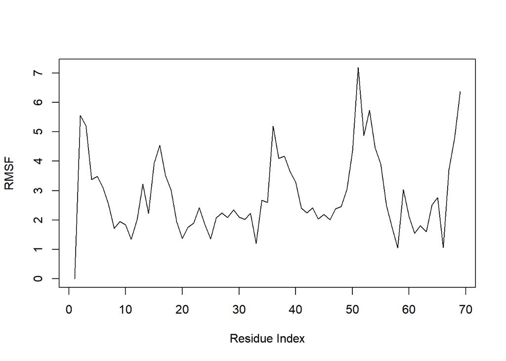

```r
# RMSF
rmsf_vals <- rmsf(xyz)
plot(rmsf_vals, typ="l", ylab="RMSF", xlab="Residue Index")
```

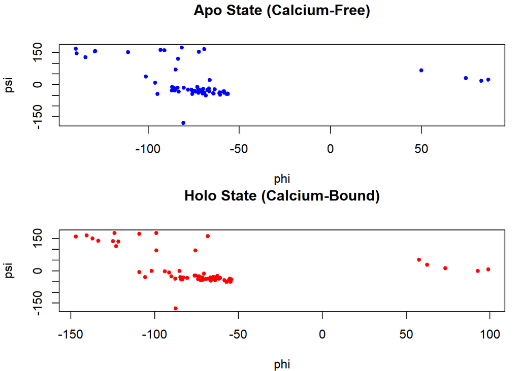

```r
# calculate torsion
tor_apo  <- torsion.pdb(apo)
tor_holo <- torsion.pdb(holo)

par(mfrow = c(2, 1), mar = c(4, 4, 3, 1))
# Apo Ramachandran plot
valid_apo <- !is.na(tor_apo$phi) & !is.na(tor_apo$psi)
plot(tor_apo$phi[valid_apo], tor_apo$psi[valid_apo],
     xlab = "phi", ylab = "psi", pch = 20, col = "blue",
     main = "")
title("Apo State (Calcium-Free)", line = 2)

# Holo Ramachandran plot
valid_holo <- !is.na(tor_holo$phi) & !is.na(tor_holo$psi)
plot(tor_holo$phi[valid_holo], tor_holo$psi[valid_holo],
     xlab = "phi", ylab = "psi", pch = 20, col = "red",
     main = "")
title("Holo State (Calcium-Bound)", line = 2)
```

```r
valid <- !is.na(tor_apo$phi) & !is.na(tor_holo$phi)
```

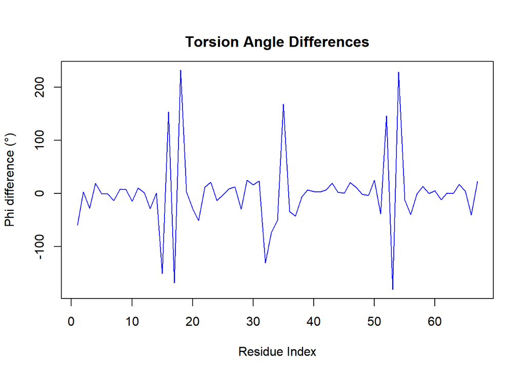

```r
phi_diff <- tor_holo$phi[valid] - tor_apo$phi[valid]
psi_diff <- tor_holo$psi[valid] - tor_apo$psi[valid]

# Phi difference plot
plot(phi_diff, type = "l", ylab = "Phi difference (°)", xlab = "Residue Index", col = "blue")
title(main = "Torsion Angle Differences", outer = FALSE, line = 1)
```

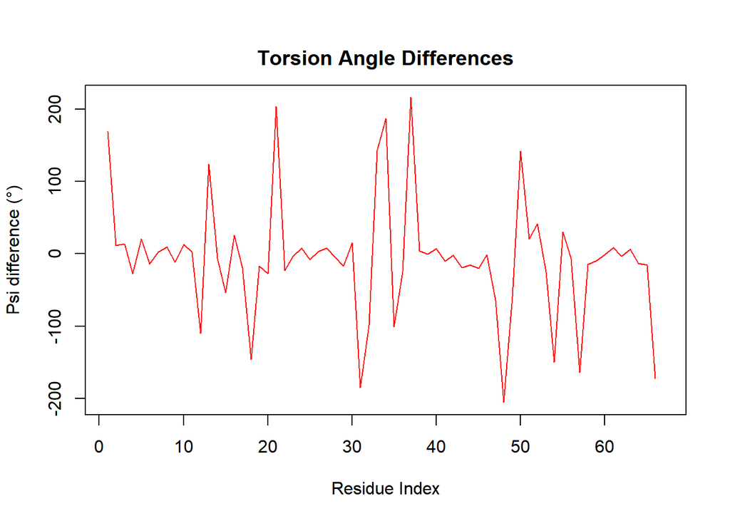

```r
# Psi difference plot
plot(psi_diff, type = "l", ylab = "Psi difference (°)", xlab = "Residue Index", col = "red")
title(main = "Torsion Angle Differences", outer = FALSE, line = 1)
```